# R Notebook sandbox: Assignment “Datasets” (10 points)

```r
library(devtools);
my.source = 'local';
local.path = "C:/_git_/WSU_STATS419_FALL2020/";
local.data.path = ""
source( paste0(local.path,"functions/libraries.R"), local=T );
```

# 1 Matrix

Create the “rotate matrix” functions as described in lectures. Apply to the example “myMatrix”.

```r
source( paste0(local.path,"functions/functions-matrix.R"), local=T );


myMatrix = matrix ( c (
                                            1, 0, 2,
                                            0, 3, 0,
                                            4, 0, 5
                                            ), nrow=3, byrow=T);
```

```r
transposeMatrix(myMatrix);
```

```
##      [,1] [,2] [,3]
## [1,]    1    0    4
## [2,]    0    3    0
## [3,]    2    0    5
```

```r
rotateMatrix90(myMatrix);  # clockwise ...
```

```
##      [,1] [,2] [,3]
## [1,]    4    0    1
## [2,]    0    3    0
## [3,]    5    0    2
```

```r
rotateMatrix180(myMatrix);
```

```
##      [,1] [,2] [,3]
## [1,]    5    0    4
## [2,]    0    3    0
## [3,]    2    0    1
```

```r
rotateMatrix270(myMatrix);
```

```
##      [,1] [,2] [,3]
## [1,]    2    0    5
## [2,]    0    3    0
## [3,]    1    0    4
```

# 2 IRIS

Recreate the graphic for the IRIS Data Set using R. Same titles, same scales, same colors. See: https://en.wikipedia.org/wiki/Iris_flower_data_set#/media/File:Iris_dataset_scatterplot.svg

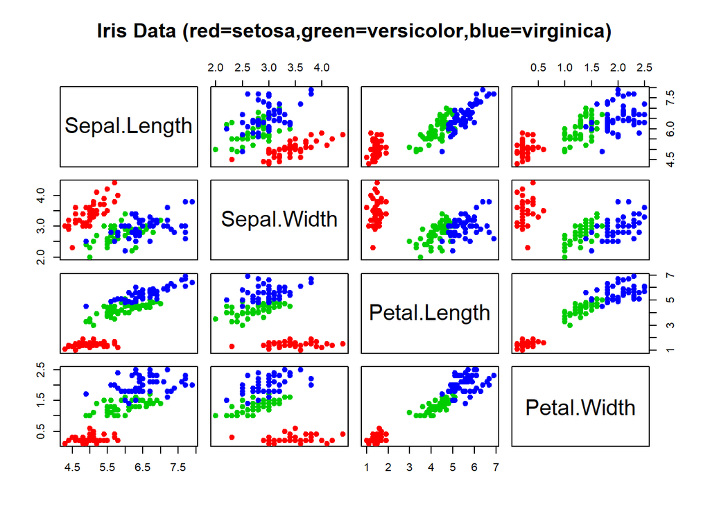

```r
palette(value = c("red" , "green3","blue"))
plot(iris[1:4], col = iris$Species, pch=19, main = "Iris Data (red=setosa,green=versicolor,blue=virginica)")
```

Edgar Anderson introduce a multivariate data set called the Iris dataset consisting of 5 attributes for Iris Flowers and a sample of 50 of each species measurements. The measurements are Sepal Length, Sepal Width, Petal Length, and Petal Width for each flower.

# 3 Personality

## 3.1 Cleanup RAW

Import “personality-raw.txt” into R. Remove the V00 column. Create two new columns from the current column “date_test”: year and week. Stack Overflow may help: https://stackoverflow.com/questions/22439540/how-to-get-week-numbers-from-dates … Sort the new data frame by YEAR, WEEK so the newest tests are first … The newest tests (e.g., 2020 or 2019) are at the top of the data frame. Then remove duplicates using the unique function based on the column “md5_email”. Save the data frame in the same “pipe-delimited format” ( | is a pipe ) with the headers. You will keep the new data frame as “personality-clean.txt” for future work (you will not upload it at this time). In the homework, for this tasks, report how many records your raw dataset had and how many records your clean dataset has.

```r
my_data = read.table(paste0(local.path,"datasets/personality/personality-raw.txt"), sep ="|", header = TRUE, dec =".")
my_data = my_data[,-3]
my_data$date_test = as.Date(sub(" .*", "", my_data$date_test), format = '%m/%d/%Y')
my_data$WEEK = format(as.Date(my_data$date_test), "%W")
my_data$YEAR = format(as.Date(my_data$date_test), "%Y")
my_data = my_data[order(my_data$YEAR,my_data$WEEK, decreasing = TRUE),]
my_data_clean = distinct(my_data, md5_email, .keep_all = TRUE)
#write.table(my_data_clean, file = "C:/Users/blue/Desktop/STAT419/personality-clean.txt", sep = "|", row.names = TRUE)
```

Raw record had 838 records and the clean set had 678 records.

# 4 Variance and Z-scores

Write functions for doSummary and sampleVariance and doMode … test these functions in your homework on the “monte.shaffer@gmail.com” record from the clean dataset. Report your findings. For this “monte.shaffer@gmail.com” record, also create z-scores. Plot(x,y) where x is the raw scores for “monte.shaffer@gmail.com” and y is the z-scores from those raw scores. Include the plot in your assignment, and write 2 sentences describing what pattern you are seeing and why this pattern is present.

```r
monte = my_data_clean[my_data_clean$md5_email == 'b62c73cdaf59e0a13de495b84030734e',]
monte
```

|  | md5_email | date_test | V01 | V02 | V03 | V04 | V05 | V06 | V07 | V08 | V09 | V10 | V11 | V12 | V13 | V14 | V15 | V16 | V17 | V18 | V19 | V20 | V21 | V22 | V23 | V24 | V25 | V26 | V27 | … |
| --- | --- | --- | --- | --- | --- | --- | --- | --- | --- | --- | --- | --- | --- | --- | --- | --- | --- | --- | --- | --- | --- | --- | --- | --- | --- | --- | --- | --- | --- | --- |
| 1 | b62c73cdaf59e0a13de495b84030734e | 2020-04-06 | 3.4 | 4.2 | 2.6 | 4.2 | 2.6 | 2.6 | 4.2 | 2.6 | 3.4 | 4.2 | 4.2 | 3.4 | 3.4 | 4.2 | 5 | 3.4 | 5 | 3.4 | 1.8 | 2.6 | 2.6 | 2.6 | 4.2 | 3.4 | 5 | 2.6 | 4.2 | … |

## 4.1 doMode

```r
doMode = function(x) #from stackoverflow https://stackoverflow.com/questions/2547402/how-to-find-the-statistical-mode
{
  ux <- unique(x)
  tab <- tabulate(match(x, ux))
  ux[tab == max(tab)]
}
```

## 4.2 Variance

### 4.2.1 Naive

#### 4.2.1.1 Problems with this approach

### 4.2.2 Traditional Two Pass

```r
doSampleVariance = function(x,method='two-pass')
{
  #NAIVE METHOD
  if(method=='naive')
  {
    return(sum((x-mean(x))^2)/(length(x)-1));
  }
  else
  {
    #two-pass algo
    sumsq = 0
    for (i in x)
    {
      sumsq = sumsq + ((i - mean(x))*(i-mean(x)))
    }
    return(sumsq / (length(x)-1));
  }
}
```

## 4.3 doSummary

```r
doSummary = function(x) #worked on this with Nic
{
  #length
  print("dimension")
  print(dim(x))
  #number of NAs
  print("number of NAs")
  print(sum(is.na(x)))
  #mean
  print("mean of each column")
  print(colMeans(x))
  #median
  print("median of each column")
  print(colMedians(data.matrix(x)))
  #mode
  print("mode of each column")
  print(sapply(x,doMode))
  #variance
  print("variance of each column")
  print(sapply(x,doSampleVariance))
  #sd
  print("sd of each column")
  print(sapply(x,sd))
}

doSummary(my_data_clean[,3:62])
```

```
## [1] "dimension"
## [1] 678  60
## [1] "number of NAs"
## [1] 0
## [1] "mean of each column"
##      V01      V02      V03      V04      V05      V06      V07      V08
## 3.420059 3.586431 2.435988 4.043068 4.177581 3.816519 3.881416 3.164012
##      V09      V10      V11      V12      V13      V14      V15      V16
## 4.321534 3.857817 2.997640 3.283186 3.672566 3.830678 3.899115 4.089086
##      V17      V18      V19      V20      V21      V22      V23      V24
## 4.303835 4.074926 3.484956 2.341593 3.024779 3.843658 4.172861 3.791740
##      V25      V26      V27      V28      V29      V30      V31      V32
## 2.414749 4.139823 3.623009 3.555752 2.953982 3.808260 3.870796 3.612389
##      V33      V34      V35      V36      V37      V38      V39      V40
## 3.999410 3.807080 3.501475 4.189381 3.122714 4.142183 4.033628 3.943953
##      V41      V42      V43      V44      V45      V46      V47      V48
## 3.717404 3.820059 3.718584 3.706785 3.861357 3.952212 3.945133 3.548673
##      V49      V50      V51      V52      V53      V54      V55      V56
## 3.761062 3.355162 3.568732 3.968732 4.281416 4.103245 3.303245 3.828319
##      V57      V58      V59      V60
## 3.783481 3.926254 3.732743 3.687906
## [1] "median of each column"
##  [1] 3.4 3.4 2.6 4.2 4.2 4.2 4.2 3.4 4.2 4.2 3.4 3.4 3.4 4.2 4.2 4.2 4.2
## [18] 4.2 3.4 1.8 3.4 4.2 4.2 4.2 2.6 4.2 3.4 3.4 2.6 4.2 4.2 3.4 4.2 4.2
## [35] 3.4 4.2 3.4 4.2 4.2 4.2 4.2 4.2 3.4 3.4 4.2 4.2 4.2 3.4 4.2 3.4 3.4
## [52] 4.2 4.2 4.2 3.4 4.2 4.2 4.2 4.2 3.4
## [1] "mode of each column"
## $V01
## [1] 3.4
##
## $V02
## [1] 4.2
##
## $V03
## [1] 1.8
##
## $V04
## [1] 4.2
##
## $V05
```

[output cut: 190 more lines]

```
## 0.9766566 0.6952738 0.8707062 1.0577394 0.9686583 0.9235710 1.0356153
##       V15       V16       V17       V18       V19       V20       V21
## 0.8256410 0.7537393 0.7175064 0.7762670 0.8806357 0.9646079 1.1199703
##       V22       V23       V24       V25       V26       V27       V28
## 0.9087038 0.7983556 0.8747515 1.1333096 0.8504971 0.8621716 1.0133762
##       V29       V30       V31       V32       V33       V34       V35
## 1.0700738 0.7943242 0.9586747 0.9964012 0.8660337 0.9024225 0.9996591
##       V36       V37       V38       V39       V40       V41       V42
## 0.7423102 1.1160374 0.8405997 0.8661987 0.9014269 1.0473111 0.9290703
##       V43       V44       V45       V46       V47       V48       V49
## 0.8677258 0.9448209 0.8484651 0.9218597 0.8757010 1.0356523 0.9515998
##       V50       V51       V52       V53       V54       V55       V56
## 1.0289150 1.0321115 0.8649221 0.8088011 0.8375713 0.9868058 0.9329171
##       V57       V58       V59       V60
## 0.8648520 0.9227093 0.9871053 0.9868566
```

## 4.4 Z-Scores

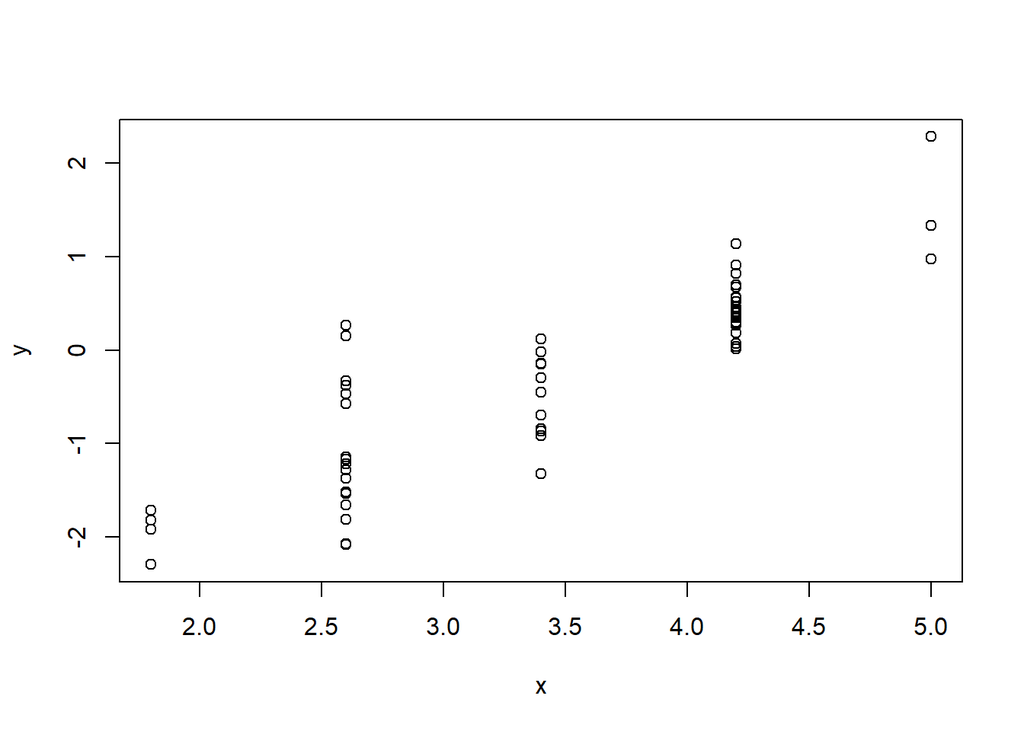

```r
zscore = function(x,y) #calculate zscore
{
  #(x-mean)/sd
  mean = colMeans(x)
  sd = sapply(x,sd)
  vec = c()
  for (i in 1:ncol(y))
  {
    vec = c(vec,(y[,i]-data.frame(mean[i]))/data.frame(sd[i]))
  }
  return(vec);
}

#zscore taking the measurable columns
xlist = as.list(monte[,3:62])
ylist = zscore(my_data_clean[,3:62],monte[,3:62])
zscoretable = do.call(rbind, Map(data.frame, x=xlist, y=ylist))
plot(zscoretable)
```